# Bruhn_C12_2

## C12.5.6 一般せん断座屈許容値

本節では、一般せん断座屈許容値曲線を示す。これらの曲線は、特定の材料に限定されないという意味で一般的である。

せん断座屈方程式は以下の通りである。

$$\frac{F_s}{\eta} = \frac{K_s}{J} \cdot \frac{U}{2t_F}$$
—(C12.5.20)

ここで、

$$\eta = \frac{2E_T}{E + E_T} \quad \text{for } F_1 = \sqrt{3} F_{\text{scr}}, \quad \therefore \gamma_1 = \sqrt{3}$$

$$J = \frac{b^2 U}{\pi^2 D}$$

以下の例は、せん断許容値を求める方法を示している。

**与条件**: 1. 材料: PH15-7Mo (RH1050) 鋼（室温において） 2. 特性: - $E = 30 \times 10^6 \text{ psi}$ - $G'_c = 38000 \text{ psi}$ ( $s = 3/16$ および $t_c = 0.001 \text{ in.}$ に対して) - $F_{\text{cy}} = 190000 \text{ psi}$ - $\mu = 0.3$ 3. 幾何学的形状: - $c = 0.25 \text{ in.}$ - $t_F = 0.0075 \text{ in.}$ - $a = 40 \text{ in.}$ - $b = 20 \text{ in.}$ - $s \times t_c = 3/16 \times 0.001 \text{ in.}$

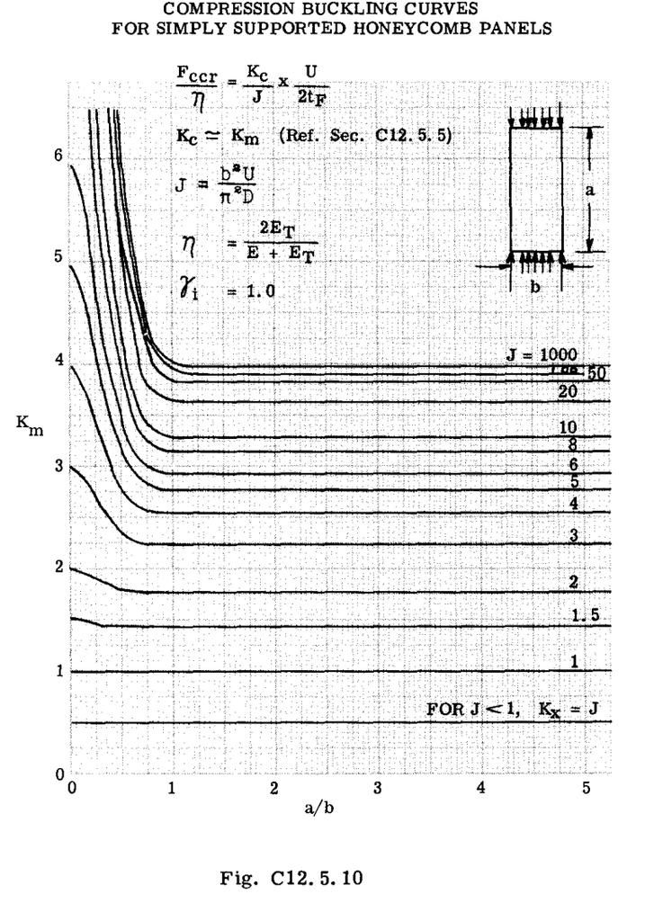

単純支持ハニカムパネルの圧縮座屈曲線

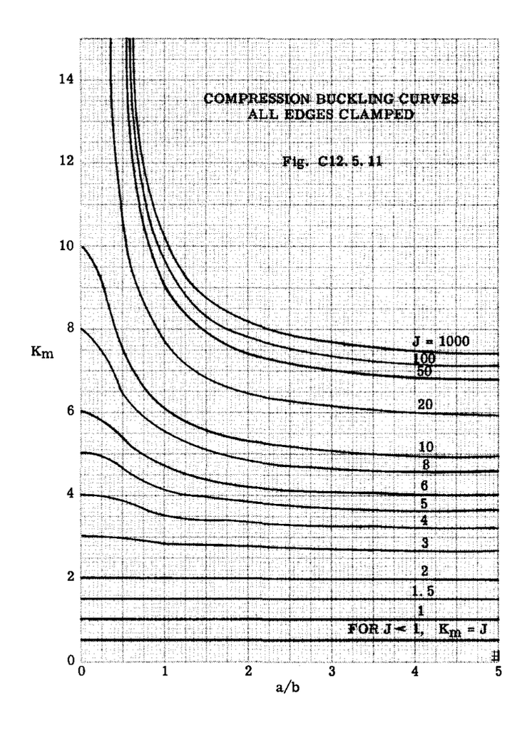

全辺固定ハニカムパネルの圧縮座屈曲線

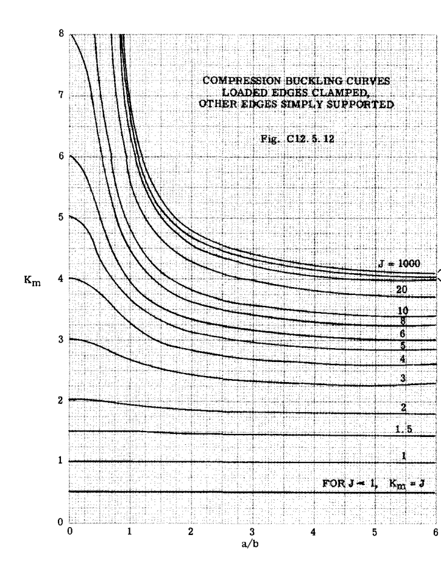

載荷辺が固定、他辺が単純支持のハニカムパネルの圧縮座屈曲線

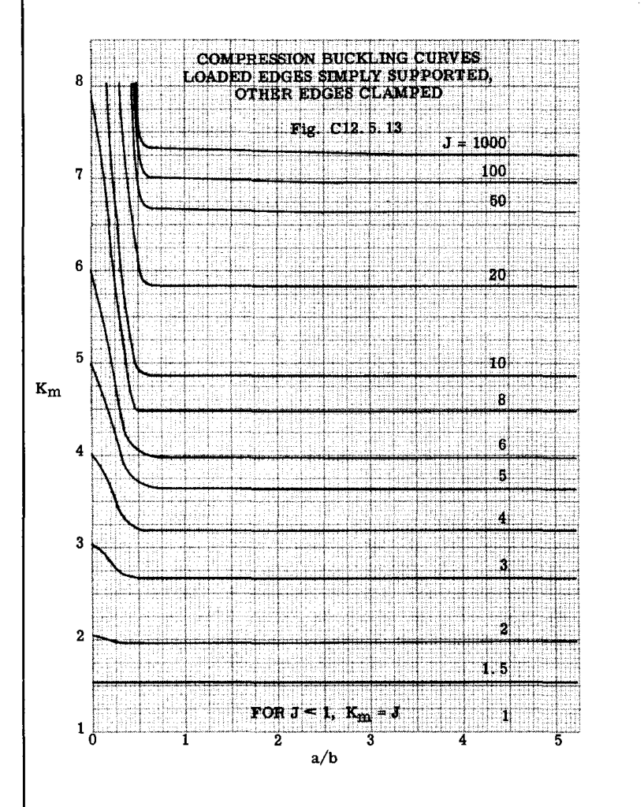

載荷辺が単純支持、他辺が固定のハニカムパネルの圧縮座屈曲線

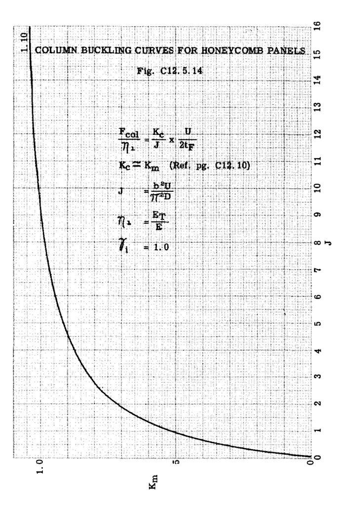

ハニカムパネルのコラム座屈曲線

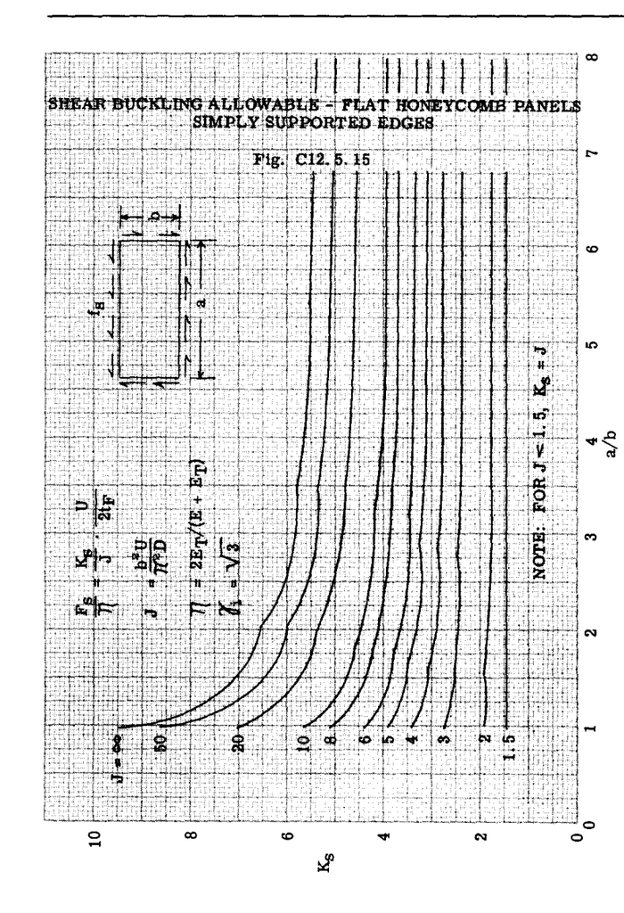

単純支持の平らなハニカムパネルのせん断座屈許容値

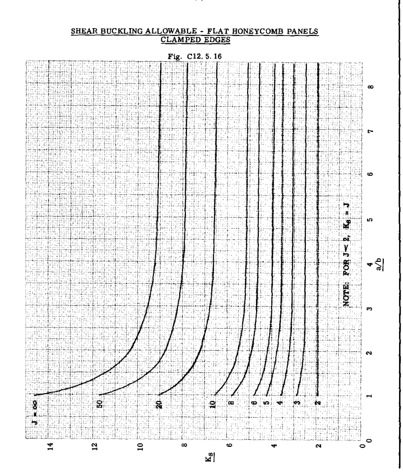

固定端の平らなハニカムパネルのせん断座屈許容値

## C12.5.7 二軸圧縮

一般座屈許容値 - 本節では、一般二軸圧縮座屈許容値曲線を示す。これらは、特定の材料に限定されないという意味で一般的である。二軸圧縮座屈方程式は以下の通りである。

$$\frac{F_{\text{xcr}}}{\eta} = \frac{K_x}{J} \cdot \frac{U}{2t_F} \quad \text{or} \quad \frac{F_{\text{ycr}}}{\eta} = \frac{K_y}{J} \cdot \frac{U}{2t_F}$$
—(C12.5.21)

ここで、

$$\eta = \frac{2E_T}{E + E_T} \quad \text{for } F_1 = F_{\text{xcr}} \sqrt{1 - \gamma + \gamma^2}$$

$$\gamma = \frac{f_y}{f_x}, \quad \therefore \gamma_1 = \sqrt{1 - \gamma + \gamma^2}$$

$$J = \frac{b^2 U}{\pi^2 D}$$

以下の例は、二軸圧縮座屈許容値を求める方法を示している。

**与条件**: 1. 材料: PH15-7Mo (RH1050)（室温において）

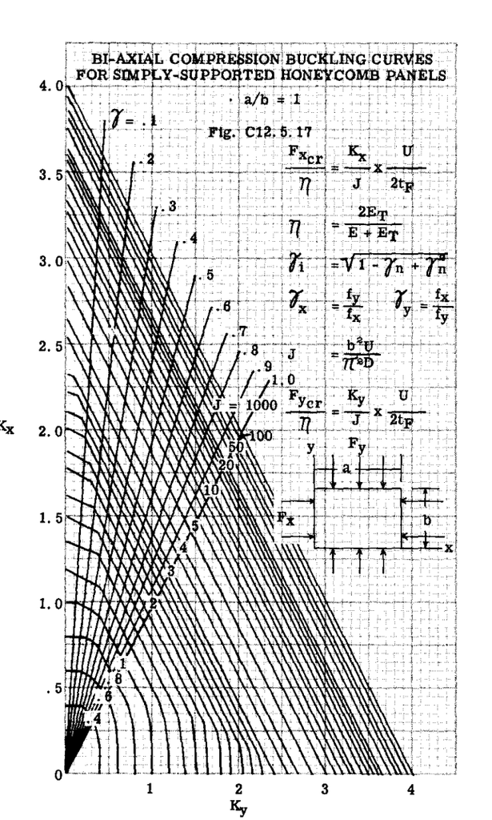

単純支持ハニカムパネルの二軸圧縮座屈曲線 (a/b=1)

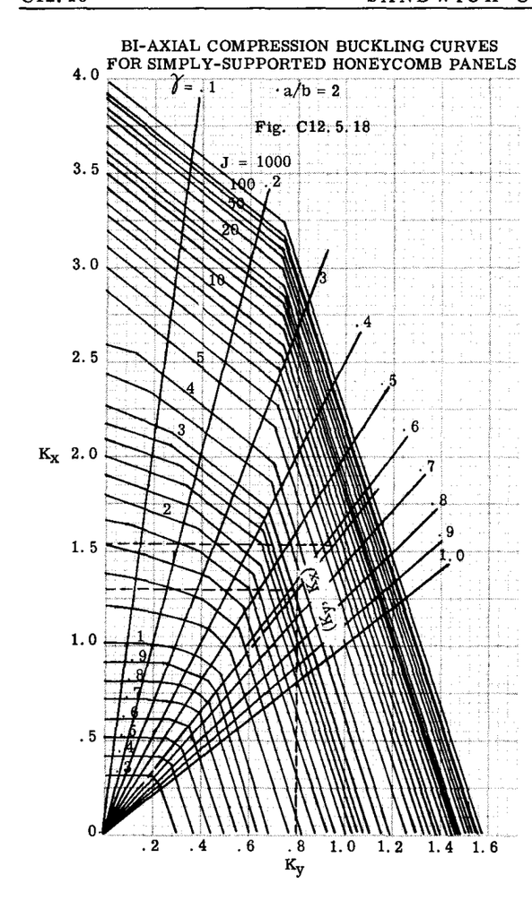

単純支持ハニカムパネルの二軸圧縮座屈曲線 (a/b=2)

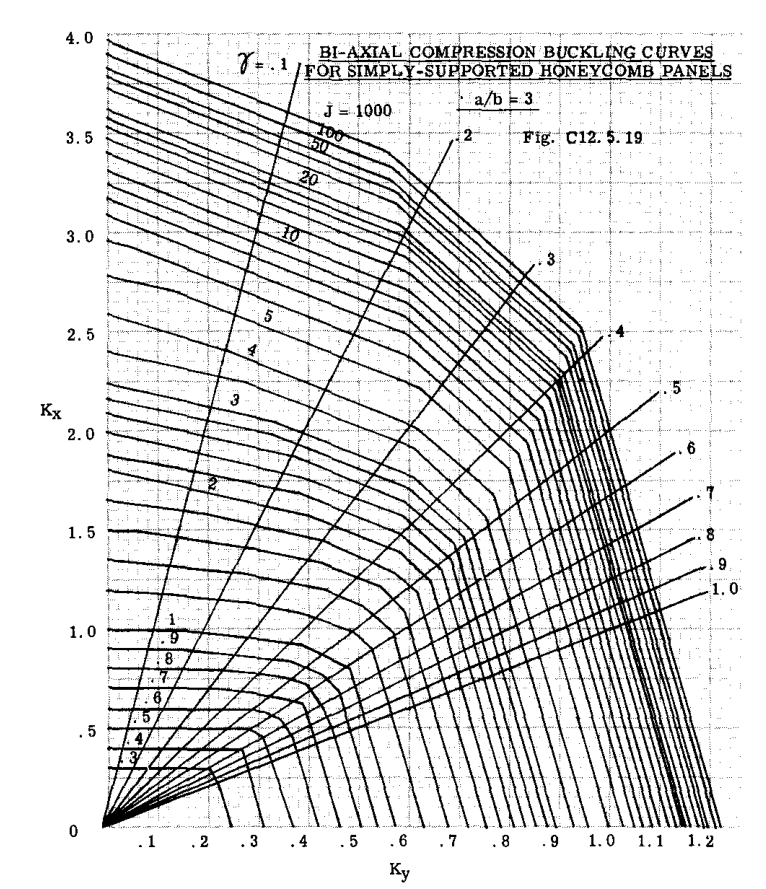

単純支持ハニカムパネルの二軸圧縮座屈曲線 (a/b=3)

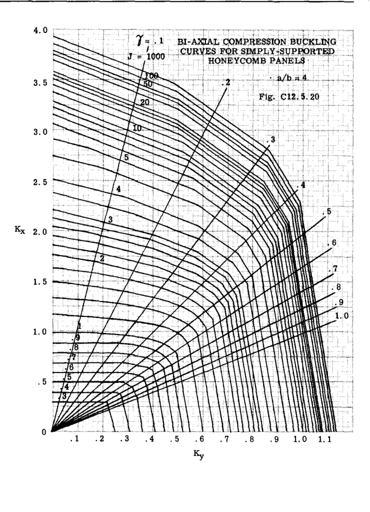

単純支持ハニカムパネルの二軸圧縮座屈曲線 (a/b=4)

2. 特性:
   - $E = 30 \times 10^6 \text{ psi}$
   - $G'_c = 38000 \text{ psi}$ ( $s = 3/16 \text{ in.}$ , $t_c = 0.001 \text{ in.}$ )
   - $F_{\text{cy}} = 190000 \text{ psi}$
3. 幾何学的形状:
   - $c = 0.50 \text{ in.}$
   - $t_F = 0.010 \text{ in.}$
   - $a = 40 \text{ in.}$
   - $b = 20 \text{ in.}$
4. 端部条件:
   - 辺は単純支持
5. 荷重:
   - $f_x = 100000 \text{ psi}$
   - $f_y = 50000 \text{ psi}$
   - $\therefore \gamma = 0.5$

**手順**: 1. $a/b = 2$ , $b/c = 40$ , $K_t = 0.02$ を計算する。 2. $U = G'_c (c + 2t_F) = 19800 \text{ lb./in.}$
$$D = \frac{E t_F (c + t_F)^2}{2(1 - \mu^2)} = 42900$$

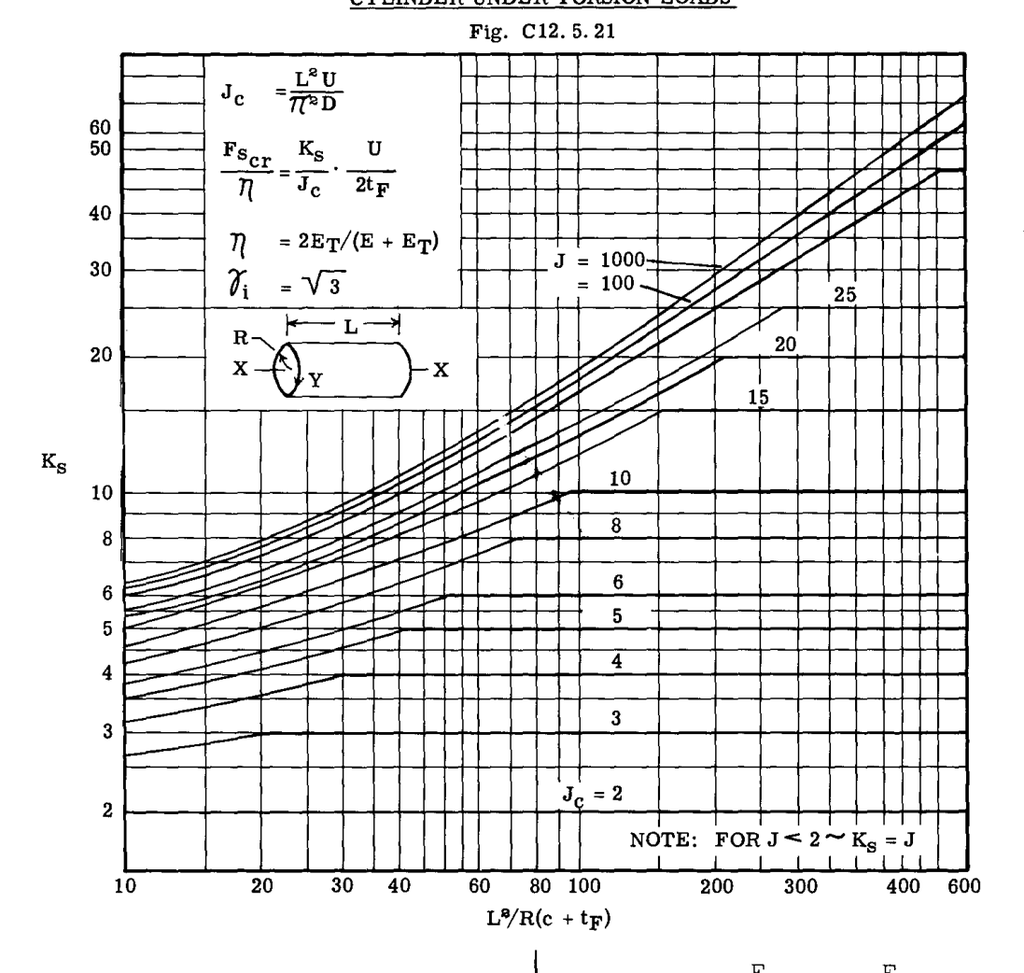

ねじり荷重を受ける単純支持サンドイッチ円筒の座屈

## C12.5.8 二軸圧縮およびせん断

応力比の概念を使用して、二軸圧縮およびせん断荷重を受ける平らなハニカムサンドイッチパネルを分析することができる。文献4の曲線は、以下の近似相互作用方程式を導出するために使用される。

$$R_c + R_s^2 = 1$$
—(C12.5.22)

ここで、

$$R_c = \frac{F_{\text{xmax}}}{F_x} \quad \text{or} \quad \frac{F_{\text{ymax}}}{F_y}$$

$$R_s = \frac{F_{\text{smax}}}{F_s}$$

$$\frac{F_x}{\eta}, \frac{F_y}{\eta}, \text{ and } \frac{F_s}{\eta} = (K_x, K_y, \text{ and } K_s) \cdot \frac{U}{2t_F} \quad \text{それぞれ}$$

$$\eta = \frac{2E_T}{E + E_T}$$

$$\gamma_1 = (1 - \gamma + \gamma^2 + 3\lambda^2)^{1/2} \quad \text{for } F_x$$

$$\gamma_1 = [\lambda^2 (1 - \gamma + \gamma^2) + 3\gamma^2]^{1/2} \quad \text{for } F_s$$
—(C12.5.23)

(C12.52ページを参照)

$$\gamma = \frac{f_y}{f_x}$$

$$\lambda = \frac{1}{\lambda_1} = \frac{f_s}{f_x}$$

$F_{\text{xmax}}$ および $F_{\text{ymax}}$ は、 $\gamma$ および $\lambda$ が一定に保たれる場合の、それぞれ $x$ および $y$ 方向の許容圧縮応力である。

$F_{\text{smax}}$ は、 $\gamma$ および $\lambda$ が一定に保たれる場合の許容せん断応力である。

したがって、

$$\frac{F_{\text{xmax}}}{\eta} = \frac{K_x K_{\lambda}}{J} \cdot \frac{U}{2t_F}$$
—(C12.5.24)

または、

$$\frac{F_{\text{smax}}}{\eta} = \frac{K_s K_{\lambda_1}}{J} \cdot \frac{U}{2t_F}$$
—(C12.5.25)

ここで、

$$K_{\lambda} = \frac{1}{2 \lambda^2 (K_x/K_s)^2} \left\{ -1 + \left[ 1 + (2 \lambda \frac{K_x}{K_s})^2 \right]^{1/2} \right\}$$
—(C12.5.26)

$$K_{\lambda_1} = \frac{(K_s/K_x)\lambda_1}{2} \left\{ -1 + \left[ 1 + (\frac{2 K_x}{K_s \lambda_1})^2 \right]^{1/2} \right\}$$
—(C12.5.27)

**手順**:

1. 与条件: $a, b, c, t_F, s, t_c, f_x, f_y, f_s$ および材料。
2. 適切なページ（C12.15 および C12.16）から $K_x$ および $K_y$ を求める。
3. C12.17 ページから $K_s$ を求める。
4. $f_s/f_x (\lambda) \le 1$ の場合、式 C12.5.26 から $K_{\lambda}$ を計算する。
5. 式 C12.5.23 から $\gamma_1$ を計算する。
6. $$\frac{F_{\text{xmax}}}{\eta} = \frac{K_x K_{\lambda}}{J} \cdot \frac{U}{2t_F}$$
   $F_1 = \gamma_1 F_{\text{xmax}}$ に対する $\eta$ 。
7. $f_x/f_s (\lambda_1) < 1$ の場合、式 C12.5.27 から $K_{\lambda_1}$ を求める。
8. 式 C12.5.23 から $\gamma_1$ を求める。
9. $$\frac{F_{\text{smax}}}{\eta} = \frac{K_s K_{\lambda_1}}{J} \cdot \frac{U}{2t_F}$$
   $F_1 = \gamma_1 F_{\text{smax}}$ に対する $\eta$ 。
10. Fig. C12.5.2b から $F_{\text{xmax}}$ または $F_{\text{smax}}$ を求める。
11. $$\text{M.S.} = \frac{F_{\text{xmax}}}{f_x} - 1 \quad \text{または} \quad \frac{F_{\text{smax}}}{f_s} - 1$$

## C12.6 曲面ハニカムパネルの破壊モード

### C12.6.1 概要

ハニカムサンドイッチで構成された曲面パネルは、パネル全体の一般不安定性または面シートの局所不安定性のいずれかによって破壊する可能性がある。本節では前者の破壊について考慮し、平板パネルに対して考慮された局所不安定性破壊は曲面パネルに対しても使用できる。パネルの一般不安定性に影響を与える荷重は、いずれかの方向の軸圧縮（ $N_x$ または $N_y$ ）、面内せん断（ $q_s$ ）、および面内曲げモーメント（ $M_{\text{bx}}$ および $M_{\text{by}}$ ）である。

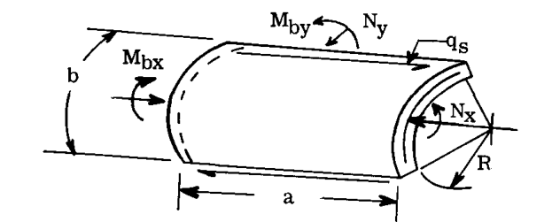

荷重を受ける曲面パネル

### C12.6.2 一軸圧縮 - 曲面パネル (文献 6)

一軸圧縮許容値は、一般座屈方程式として提示される。曲線は以下の方程式から展開できる。

$$K_x = \frac{\left[ 1 + \left(\frac{n}{m}\right)^2 \left(\frac{a}{b}\right)^2 \right]^2}{\frac{1}{m^2} \left(\frac{a}{b}\right)^2 + \frac{1}{J} \left[ 1 + \left(\frac{n}{m}\right)^2 \left(\frac{a}{b}\right)^2 \right]} + \frac{Z^2 \left(\frac{a}{b}\right)^2}{\pi^4 m^2 \left[ 1 + \left(\frac{n}{m}\right)^2 \left(\frac{a}{b}\right)^2 \right]^2}$$
—(C12.6.1)

$$J = \frac{b^2 U}{\pi^2 D}$$

$$Z = \frac{2b^2 \sqrt{1 - \mu^2}}{R (c + t_F)}$$
—(C12.6.2)

$$\frac{F_x}{\eta} = \frac{K_x}{J} \cdot \frac{U}{2t_F}$$
—(C12.6.3)

$$\eta = \frac{2E_T}{E + E_T} \quad \text{for } F_1 = F_x$$

$$\therefore \gamma_1 = 1.0$$

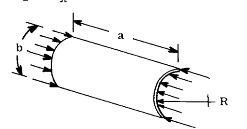

一軸圧縮を受ける曲面パネル

以下の例は、これらの方程式の適用を示している。

**与条件**: 1. 材料: PH15-7Mo (RH1050)（室温において） 2. 特性: - $E = 30 \times 10^6 \text{ psi}$ - $G'_c = 38000 \text{ (sxtc = 3/16 x .001 in.)}$ - $F_{\text{cy}} = 190000 \text{ psi}$ - $\mu = 0.30$ 3. 幾何学的形状: - $t_F = 0.005 \text{ in.}$ - $c = 0.5 \text{ in.}$ - $b = 25 \text{ in.}$ （周方向幅） - $R = 50 \text{ in.}$ （曲率半径） 4. 端部条件: - 辺は単純支持

**計算**: 1.
$$D = \frac{E t_F (c + t_F)^2}{2(1 - \mu^2)} = 21000$$
2. $U = G'_c (c + 2t_F) = 38000 \times 0.51 = 19400 \text{ lb/in.}$ 3.
$$J = \frac{b^2 U}{\pi^2 D} = 59$$
4.
$$Z = \frac{2b^2 \sqrt{1 - \mu^2}}{R(c + t_F)} = 47.0$$
$K_x = 9.2$ (最小) (式 C12.6.1 を参照) 6.
$$\frac{F_x}{\eta} = \frac{9.2 \times 19400}{59 \times 0.010} = 303000 \text{ psi}$$
7. $\gamma_1 = 1.0$ 8. $F_x = 170000 \text{ psi}$ (Fig. C12.5.2b を参照)

## 一般不安定性 - 円筒

### C12.6.3 一軸圧縮

円筒の一軸圧縮許容値は、一般座屈方程式として提示される。

曲線は以下の方程式から展開できる。

$$K_x = \frac{(m^2 + n^2 \beta_1^2)^2}{m^2 \left[ 1 + \frac{m^2 + n^2 \beta_1^2}{J_c} \right]} + \frac{0.0374 m^2 \left[ \frac{L^2}{R(c + t_F)} \right]^2}{(m^2 + n^2 \beta_1^2)^2}$$
—(C12.6.4)

$$J_c = \frac{L^2 U}{\pi^2 D}$$

$$\beta_1 = \frac{L}{2 \pi R}$$

$$\frac{F_{\text{xcr}}}{\eta} = \left( \frac{K_x}{J_c} \right) \frac{U}{2t_F}$$
—(C12.6.5)

$$\eta = \frac{2E_T}{E + E_T} \quad \text{for } F_1 = F_x$$

$$\therefore \gamma_1 = 1.0$$

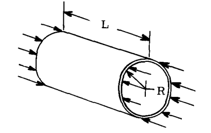

一軸圧縮を受ける円筒

以下の例は、円筒の座屈係数方程式の適用を示している。

**例**: 端部が単純支持されたハニカム円筒の座屈応力を求めよ。

**与条件**: 1. 材料: PH15-7Mo (RH1050) 鋼 2. 特性: - $E = 30 \times 10^6 \text{ psi}$ - $G'_c = 38000 \text{ psi}$ ( $s = 3/16$ および $t_c = 0.001$ に対し) - $F_{\text{cy}} = 190000 \text{ psi}$ 3. 幾何学的形状: - $c = 0.5 \text{ in.}$ - $t_F = 0.020 \text{ in.}$ - $L = 50 \text{ in.}$ - $R = 50 \text{ in.}$

**手順**: 1. 式 C12.6.4 から $K_x = 30.8$ を計算する。 2.
$$\text{計算 } \frac{F_{\text{xcr}}}{\eta} = \frac{30.8 \times 20500}{0.040 \times 58.3} = 270000 \text{ psi}$$
3. $\gamma_1 = 1.0$ 4. 実際の座屈応力を求めるには、Fig. C12.5.2b の塑性補正曲線を参照し、 $F_{\text{xcr}} = 166000 \text{ psi}$ を読み取る。

### C12.6.4 ねじり (文献 D12)

ねじり座屈許容値方程式は、一般座屈許容値として提示され、任意の材料に適用可能である。

これらの方程式は、許容値をせん断応力として与える。以下の関係を覚えておく必要がある。

$$q_s = \frac{T}{2 \pi R^2}$$
—(C12.6.6)

$$_fs = \frac{q_s}{2t_F} = \frac{T}{4 \pi R^2 t_F}$$
—(C12.6.7)

$$\frac{F_{\text{scr}}}{\eta} = \frac{K_s}{J_c} \cdot \frac{U}{2t_F}$$
—(C12.6.8)

ここで、 $T$ は $\text{in.lb.}$ 単位のねじりモーメントである。

本節で提示される曲線は、任意の材料および与えられた円筒の幾何学的形状に対して一般的である。曲線は、定義されたパラメータに対するせん断座屈係数の形式である。

臨界座屈応力は、材料の比例限度を超える場合、塑性効果に対して補正されなければならない。

これらの曲線の使用を説明するために、以下の例を示す。

**与条件**: 1. 材料: PH15-7Mo (RH1050) 鋼 2. 特性: - $E = 30 \times 10^6 \text{ psi}$ - $G'_c = 38000 \text{ psi}$ ( $s = 3/16$ および $t_c = 0.001$ に対し) - $F_{\text{cy}} = 190000 \text{ psi}$ 3. 幾何学的形状: - $t_F = 0.05 \text{ in.}$ - $c = 0.5 \text{ in.}$ - $L = 40 \text{ in.}$ - $R = 25 \text{ in.}$

**手順**: 1. 計算:
$$J_c = \frac{b^2 U}{\pi^2 D} = 14.95$$
$$\frac{L^2}{R(c + t_F)} = 116$$
2. Fig. C12.5.21 の曲線から $K_s = 13.0$ 3. $U = 38000(0.60) = 22800$ 4.
$$\frac{F_{\text{scr}}}{\eta} = \frac{13 \times 22800}{14.95 \times 0.10} = 198000 \text{ psi}$$
5. $\gamma_1 = \sqrt{3}$ に対する Fig. C12.5.2b を使用して、 $F_{\text{scr}} = 102000 \text{ psi}$

### C12.6.5 均一な外側横圧力 (文献 7)

以下の節では、単純支持されたハニカム円筒の許容座屈応力を決定するための方程式を提示する。

許容値は、以下の方程式から展開される。

$$K_y = \frac{(1 + n^2 \beta_1^2)^2}{n^2 \beta_1^2 \left[ 1 + \frac{1 + n^2 \beta_1^2}{J_c} \right]} + \frac{0.0374 \left[ \frac{L^2}{R(c + t_F)} \right]^2}{n^2 \beta_1^2 (1 + n^2 \beta_1^2)^2}$$
—(C12.6.9)

$$J_c = \frac{L^2 U}{\pi^2 D}$$

$$\beta = \frac{L}{2 \pi R}$$

$$\frac{F_{\text{ycr}}}{\eta} = \frac{K_y}{J_c} \times \frac{U}{2t_F}$$
—(C12.6.10)

$$F_{\text{ycr}} = \frac{p R}{2t_F} \quad p = \frac{2 F_{\text{ycr}} t_F}{R}$$
—(C12.6.11)

$p =$ 均一な外側横圧力 ( $\text{psi}$ )

以下の例は、円筒に対する横方向座屈係数方程式の適用を示している。

**例**: 端部が単純支持され、横圧力のみを受けるハニカム円筒の座屈応力を求めよ。

**与条件**: 1. 材料: PH15-7Mo (RH1050) 鋼 2. 特性: - $E = 30 \times 10^6 \text{ psi}$ - $G'_c = 38000 \text{ psi}$ ( $s = 3/16$ および $t_c = 0.001$ に対し) - $F_{\text{cy}} = 190000 \text{ psi}$ 3. 幾何学的形状: - $c = 1 \text{ in.}$ - $t_F = 0.1 \text{ in.}$ - $L = 50 \text{ in.}$ - $R = 30 \text{ in.}$

**計算**: 1. $D = 1990000$

2. $U = G'_c (c + 2t_F) = 45600 \text{ lb./in.}$
3. $J_c = \frac{L^2 U}{\pi^2 D} = 5.8$

**手順**: 1. 式 C12.6.9 から $K_y = 4.30$ 2. $F_{\text{ycr}}/\eta = (4.30 / 5.8) \times (45600 / 0.2) = 168000 \text{ psi} \quad \gamma_1 = 1.$ 3. $F_{\text{ycr}} = 141000 \text{ psi}$ (Fig. C12.5.2b を参照) 4.
$$P_{\text{cr}} = \frac{F_{\text{ycr}} \times 2 t_F}{R} = \frac{141000 \times 0.2}{30} = 940 \text{ psi}$$

### C12.6.6 曲げモーメント

曲げモーメントを受ける単純支持円筒の許容座屈応力は、一軸圧縮荷重を受ける円筒の許容応力と同じである。曲げ応力 $f_{\text{bx}}$ は、以下の方程式から計算できる。

$$_fbx = \frac{M}{2 \pi R^2 t_F}$$
—(C12.6.12)

この応力は、節 C12.6.3 で計算された許容応力と比較することができる。軸圧縮荷重（ $f_x$ ）も存在する場合、 $f_{\text{bx}}$ は $f_x$ に直接加算でき、その総和（ $f_{\text{xz}}$ ）は、改訂または修正された一軸圧縮荷重として処理できる。この荷重は、ねじりや横圧力とともに使用することもできる。

以下の例は、その方法を示している。

**例 1**

**与条件**: 1. 材料: PH15-7Mo (RH1050) 鋼 2. 特性: - $E = 30 \times 10^6 \text{ psi}$ - $G'_c = 38000 \text{ psi}$ ( $s \times t_c = 3/16 \times 0.001 \text{ in.}$ ) 3. 幾何学的形状: - $c = 0.5 \text{ in.}$ - $t_F = 0.020 \text{ in.}$ - $L = 50 \text{ in.}$ - $R = 50 \text{ in.}$ 4. 荷重: - $M = 51 \times 10^6 \text{ in.lb.}$

**手順**:

$$_fbx = \frac{M}{2 \pi R^2 t_F} = \frac{51 \times 10^6}{2 \pi \cdot 50^2 \cdot 0.020} = 162000 \text{ psi}$$

**例 II**

**与条件**: 1. 材料: PH15-7Mo (RH1050) 鋼 2. 特性: - $E = 30 \times 10^6 \text{ psi}$ - $G'_c = 38000 \text{ psi}$ ( $s \times t_c = 3/16 \times 0.001 \text{ in.}$ ) - $F_{\text{cy}} = 190000 \text{ psi}$ 3. 幾何学的形状: - $c = 0.80 \text{ in.}$ - $t_F = 0.080 \text{ in.}$ - $L = 50 \text{ in.}$ - $R = 50 \text{ in.}$ 4. 荷重: - $F_x = 50000 \text{ psi}$ - $M = 88 \times 10^6 \text{ in. lb.}$ - $f_y = 60000 \text{ psi}$ - $f_s = 24000 \text{ psi}$

**手順**:

$$_fbx = \frac{M}{2 \pi R^2 t_F} = \frac{88 \times 10^6}{2 \pi \cdot 50^2 \cdot 0.080} = 70000 \text{ psi}$$

$$_fxz = f_x + f_{\text{bx}} = 50000 + 70000 = 120000 \text{ psi}$$

$$\gamma = \frac{f_y}{f_{\text{xz}}} = \frac{60000}{120000} = 0.5$$

$$\lambda = \frac{f_s}{f_{\text{xz}}} = \frac{24000}{120000} = 0.2$$

$$_Fx = 150000 \text{ psi} \quad \text{(節 C12.6.8 を参照)}$$

$$\text{M.S.} = \frac{F_x}{f_{\text{xz}}} - 1 = \frac{150000}{120000} - 1 = 0.25$$

### C12.6.7 横荷重および軸圧縮

以下の節では、外側均一横圧力および軸圧縮を受ける単純支持ハニカム円筒の許容座屈応力を決定するための方程式を提示する。

$$K_x = \frac{(m^2 + n^2 \beta_1^2)^2}{(m^2 + n^2 \beta_1^2) \left[ 1 + \frac{m^2 + n^2 \beta_1^2}{J_c} \right]} + \frac{0.0374 m^4 \left[ \frac{L^2}{R(c + t_F)} \right]^2}{(m^2 + n^2 \beta_1^2) (m^2 + n^2 \beta_1^2)^2}$$
—(C12.6.13)

$$J_c = \frac{L^2 U}{\pi^2 D}$$

$$\beta_1 = \frac{L}{2 \pi R}$$

$$\frac{F_{\text{xcr}}}{\eta} = \frac{K_x}{J_c} \times \frac{U}{2t_F}$$
—(C12.6.14)

$$\gamma = \frac{N_y}{N_x} = \frac{1}{\gamma'}$$

$$N_y = p R$$

以下の例は、円筒に対する座屈係数方程式の適用を示している。

**例**: 横荷重と軸荷重の複合作用を受ける単純支持サンドイッチ円筒の座屈応力を求めよ。

**与条件**: 1. 材料: PH15-7Mo (RH1050) 鋼 2. 特性: - $E = 30 \times 10^6 \text{ psi}$ - $G'_c = 38000 \text{ (s = 3/16 および } t_c = 0.001 \text{ に対し) psi}$ - $F_{\text{cy}} = 190000 \text{ psi}$ 3. 幾何学的形状: - $c = 1 \text{ in.}$ - $t_F = 0.1 \text{ in.}$ - $L = 50 \text{ in.}$ - $R = 50 \text{ in.}$ 4. 荷重比: $\gamma = \frac{N_y}{N_x} = \frac{pR}{N_x} = 1/2$

**計算**: 1.
$$D = \frac{E t_F (c + t_F)^2}{2(1 - \mu^2)} = 1990000$$
2. $U = G'_c (c + 2t_F) = 45600 \text{ lb./in.}$ 3. $J_c = \frac{b^2 U}{\pi^2 D} = 5.80$

**手順**: 1. 式 C12.6.13（ $\gamma = 1/2$ ）を参照し、 $K_x = 5.5$ を計算する。 2.
$$\frac{F_x}{\eta} = \frac{5.5}{5.83} \times \frac{45600}{0.2} = 215000 \text{ psi}$$
3. $\gamma_1 = \sqrt{1 - 1 \times 0.5 + 0.5^2} = 0.866$ を使用する。 Fig. C12.5.2b から、 $F_x = 172000 \text{ psi}$ 4.
$$P_{\text{cr}} = \frac{172000 \times 0.5 \times 0.2}{50} = 345 \text{ psi}$$

### C12.6.8 軸圧縮、横荷重およびねじり

以下の節では、軸圧縮、横荷重、およびねじりを受ける単純支持ハニカムサンドイッチ円筒の許容座屈応力を決定するための曲線を提示する。これらの曲線は、文献7に提示された方程式から導出された。

以下の例は、これらの方程式の適用を示している。

**例**: 以下の荷重を受ける単純支持ハニカムサンドイッチ円筒の座屈応力を求めよ。

**与条件**: 1. 材料: PH15-7Mo (RH1050) 鋼（室温において） 2. 特性: - $E = 30 \times 10^6 \text{ psi}$ - $G'_c = 38000 \text{ psi}$ ( $s = 3/16$ および $t_c = 0.001 \text{ in.}$ に対し) - $F_{\text{cy}} = 190000 \text{ psi}$ 3. 幾何学的形状: - $c = 0.80 \text{ in.}$ - $t_F = 0.080 \text{ in.}$ - $L = 50 \text{ in.}$ - $R = 50 \text{ in.}$ 4. 荷重比: $\gamma = \frac{N_y}{N_x} = \frac{pR}{N_x} = 1/2$ , $\frac{f_s}{f_x} = 0.2$

**計算**: 1.
$$D = \frac{E t_F (c + t_F)^2}{2(1 - \mu^2)} = 1025000$$
2. $U = G'_c (c + 2t_F) = 36400 \text{ lb./in.}$ 3.
$$J_c = \frac{7150 \times 38000}{30 \times 10^6} = 9.05$$
4. 式 C12.5.21 から、 $K_x = 7.1$ 5. Fig. C12.5.21 から、 $K_s = 7.6$ 6.
$$\frac{R_s}{R_s} = \frac{f_s}{f_x} \times \frac{K_s}{K_x} = \frac{7.6}{0.2 \times 7.1} = 5.36$$
であるため 7. $R_x + R_s^2 = 1 \quad \therefore R_x = 0.96$ 8. $K'_x = R_x K_x = 0.96 \times 7.1 = 6.8$ 9.
$$\frac{F_x}{\eta} = \frac{K'_x}{J_c} \times \frac{U}{2t_F} = \frac{6.8}{9.05} \times \frac{36400}{0.16} = 171000 \text{ psi}$$

## C12.7 異なる面シートを持つ平板パネルの座屈

### C12.7.1 概要

異なる厚さの面シートまたは異なる材料の面シートを持つパネルの座屈を処理する能力は、洗練された航空機設計において特に重要である。このような方法が必要とされるのは、地上での整備や取り扱い中の損傷を防ぐために最小限の外板ゲージが要求されることが非常に多いためである。近年、熱応力の出現に伴い、異なるゲージの面シートや異なる面シート材料を使用した設計の要求が重要になってきている。室温での設計は、同様の面シート材料と見なすことができるが、温度による材料特性の影響があるため、より正確な分析のためには面シートを異なるものとして考慮しなければならない。

異なる厚さまたは異なる材料の面シートを持つサンドイッチパネルの座屈は、文献8で扱われた。本節で提示する方程式は、異なる等方性面シートのみを扱う。参照された報告書は、すべて不均等なゲージを持つ、異なる直交異方性面シートおよび同様の等方性面シートについてさらに扱っている。すべての方程式は、直交異方性コア材料を考慮している。

### C12.7.2 一軸圧縮

不均等または異なる面シートを持つハニカムパネルの設計では、節 C12.5.2、C12.5.3、および C12.5.4 で説明した局所破壊モードを依然として考慮しなければならない。ここで提示する一般座屈許容方程式は、荷重の観点から表されている。この方程式は、異なる材料特性、コア深さ、コア密度、端部拘束条件、およびパネルサイズを持つ2つの異なる等方性面シート厚さの関数である。この方程式は以下のように書くことができる。

$$N = \frac{P_M A h^2}{a^2}$$
—(C12.7.1)

ここで、 $a =$ 載荷辺

$$A = \frac{\pi^2 t_1 t_2 E_1 E_2}{(1 - \mu^2)(t_1 E_1 + t_2 E_2)} = \frac{\pi^2 Y}{(1 - \mu^2)}$$
—(C12.7.2)

$$h = \left(c + \frac{t_1 + t_2}{2}\right) \equiv c + x$$
—(C12.7.3)

$$P_M = \frac{\left[ K + \left( \frac{V_x}{C_4} + V_y \right) F \right] F}{1 + L + \left( \frac{V_x V_y}{C_4} \right) F}$$
—(C12.7.4)

$$K = c_1 + 2c_2 + c_3$$

$$F = c_1 c_3 - c_2^2 + \frac{1 - \mu}{2} c_2 K$$

$$L = \left(c_1 + \frac{1 - \mu}{2} c_2\right) \frac{V_x}{C_4} + \left(c_3 + \frac{1 - \mu}{2} c_2\right) V_y$$

コアせん断パラメータは以下の通りである。

$$V_y = \frac{K_1 Y C}{G'_{\text{cy}}}$$

$$V_x = \frac{K_1 Y C}{G'_{\text{cx}}}$$

ここで、

$$K_1 = \frac{\pi^2}{a^2 (1 - \mu^2)}$$

$$Y = \frac{t_1 t_2 E_1 E_2}{(t_1 E_1 + t_2 E_2)}$$

ハニカムコアの場合は $G'_{\text{cx}} = G'_{\text{cy}}/2$

四角セルのコアの場合は $G'_{\text{cx}} = G'_{\text{cy}}$

端部固定定数 $c_1, c_2, c_3$ 、および $c_4$ は、それぞれの端部固定条件とともに以下のようにリストされている。

#### 全辺単純支持

$$c_1 = \frac{b^2}{n^2 a^2}, \quad c_2 = 1, \quad c_3 = \frac{n^2 a^2}{b^2}, \quad c_4 = c_1$$

#### 載荷辺が単純支持で残りの辺が固定

$$c_1 = \frac{16b^2}{3n^2 a^2}, \quad c_2 = \frac{4}{3}, \quad c_3 = \frac{n^2 a^2}{b^2}, \quad c_4 = \frac{c_1}{4}$$

#### 載荷辺が固定で残りの辺が単純支持

$$c_1 = \frac{3b^2}{4a^2} \quad \text{if } n=1, \quad c_1 = \frac{b^2}{(n^2 + 1)a^2} \quad \text{if } n \ge 2$$

$$c_2 = 1, \quad c_3 = \frac{a^2 (n^4 + 6n^2 + 1)}{b^2 (n^2 + 1)}$$

$$c_4 = \frac{3b^2}{n a^2} \quad \text{if } n=1, \quad c_4 = \frac{b^2}{(n^2 + 1)a^2} \quad \text{if } n \ge 2$$

#### 全辺固定

$$c_1 = \frac{4b^2}{a^2} \quad \text{if } n=1, \quad c_1 = \frac{16b^2}{3(n^2 + 1)a^2} \quad \text{if } n \ge 2$$

$$c_2 = \frac{4}{3}, \quad c_3 = \frac{a^2 (n^4 + 6n^2 + 1)}{b^2 (n^2 + 1)}$$

$$c_4 = \frac{b^2}{a^2} \quad \text{if } n=1, \quad c_4 = \frac{4b^2}{3(n^2 + 1)a^2} \quad \text{if } n \ge 2$$

以下の例は、ハニカムパネルの許容弾性荷重を求める際、座屈方程式を適用することを示している。

**与条件**: - 材料: PH15-7Mo (RH1050) 鋼 - $E_1 = 30 \times 10^6 \text{ psi}$ - $E_2 = 25 \times 10^6 \text{ psi}$ - $G_{\text{cx}} = G_{\text{cy}} = 40000 \text{ psi}$ - 幾何学的形状: - $\mu = 0.3$ - $c = 0.1 \text{ in.}$ - $t_1 = 0.01 \text{ in.}$ - $t_2 = 0.02 \text{ in.}$ - $a = 10 \text{ in.}$ - $b = 10 \text{ in.}$ - 単純支持パネル、 $n = 1$

**計算**:

$$c_1 = 1, \quad c_2 = 1, \quad c_3 = 1, \quad c_4 = 1$$

$$K_1 = \frac{\pi^2}{100(1 - 0.09)} = 0.1083$$

$$Y = \frac{0.01 \times 0.02 \times 30 \times 10^6 \times 25 \times 10^6}{0.01 \times 30 \times 10^6 + 0.02 \times 25 \times 10^6} = \frac{0.188 \times 10^6}{10}$$

$$V_x = V_y = \frac{0.1083 imes 0.188 \times 10^6 \times 0.1}{40000} = 0.0511$$

$$L = (1 + \frac{0.7}{2} \times 1) \frac{0.0511}{1} + (1 + \frac{0.7}{2} \times 1) \cdot 0.0511 = 0.138$$

$$K = 1 + 2 \times 1 + 1 = 4$$

$$F = 1 \times 1 - 1 + \frac{0.7}{2} \times 1 \times 4 = 1.4$$

$$P_M = \frac{4 + \left[ \left(\frac{0.0511}{1} + 0.0511\right) \right] 1.4}{1 + 0.138 + \left( \frac{0.0511 \times 0.0511}{1} \right) 1.4} = 2.17$$

$$h = (0.1 + \frac{0.01 + 0.02}{2}) = 0.115$$

$$A = \frac{\pi^2 \times 0.188 \times 10^6}{0.91} = 2.04 \times 10^6$$

式 C12.7.1 からの許容荷重 $N$ は：

$$N = \frac{2.17 \times 2.04 \times 10^6 \times (0.115)^2}{100} = 584 \text{ lb/in.}$$

## C12.8 インサートに加わる荷重によって誘起されるコアせん断

### C12.8.1 概要

構造用サンドイッチ構造、特に航空機構造の使用において、サンドイッチの平面に対して垂直または傾斜した方向に荷重を加えることができるフィッティングを介して、サンドイッチに荷重を伝達することがしばしば必要となる。フィッティングは通常、サンドイッチコアを局所的に置き換える小さなインサートへの取り付けによってサンドイッチに固定される。このインサートは金属またはより高密度のコアでできていてもよく、サンドイッチの製造時に面シート間に接着される。

文献9で行われた理論的および実験的研究は、中央に小さな円形インサートを有する比較的大きな円形サンドイッチパネルで実施された。荷重は、サンドイッチパネルに垂直な方向でインサートに加えられた。コアのひずみを測定するために、作業は連続的なコア材料に限定され、1つは中程度のせん断弾性率のコアを表す木口バルサ材、もう1つは低いせん断弾性率のコアを表すコルク板であった。

この研究の結果はパネルの中心にあるインサートおよび等方性コア材料に限定されていたため、最終的な設計ケースでは、直交異方性コアおよび非中心に配置されたインサートを考慮するために、このデータに補正を加えなければならない。直交異方性コアの場合の補正は、方向せん断弾性率 $G_x$ および $G_y$ に比例して行うことができる。中心からずれて配置されたインサートの場合の補正は、端部支持に対する梁のせん断、または端部支持からの荷重の距離に反比例して行うことができる。

### C12.8.2 せん断応力分布

せん断応力は、インサートの端部またはその近くで最大になり、外縁が固定されインサートが固定されたプレートに対して与えられる。応力の径方向分布は、以下の方程式で表される。

$$f_s(r) = \frac{P I_m K}{\pi 2h I}$$
—(C12.8.1)

ここで、

$$I_m = \frac{t_F h^2}{2} \quad I = I_m + I_f \quad I_f = \frac{t^3}{6}$$

$$K = \frac{1}{r} \left[ 1 - \sqrt{r} \frac{\sqrt{r_I} \sinh a(r - r_I) + \sqrt{r_p} \sinh a(r_p - r)}{\sqrt{r_p r_I} \sinh a(r_p - r_I)} \right]$$
—(C12.8.2)

$$a = \sqrt{\frac{2 G'_c I}{c t_F E I_f}}$$
—(C12.8.3)

$r_I =$ インサートの半径、 $r_p =$ パネルの半径

面シート応力はインサートの端部で最大となり、以下の方程式で与えられる。

$$f = \frac{P(h + t)}{2 \pi t h^2} \left[ 1 + \frac{2h}{(h + t) a r_I} - \frac{2 r_p^2}{r_p^2 - r_I^2} \text{Log } \frac{r_p}{r_I} - \frac{3h^2}{(h + t) t a r_I} \right]$$
—(C12.8.4)

コア内の以下の計算されたせん断応力分布（Fig. C12.8.1）は、 $a$ および $r$ による変化を示している。

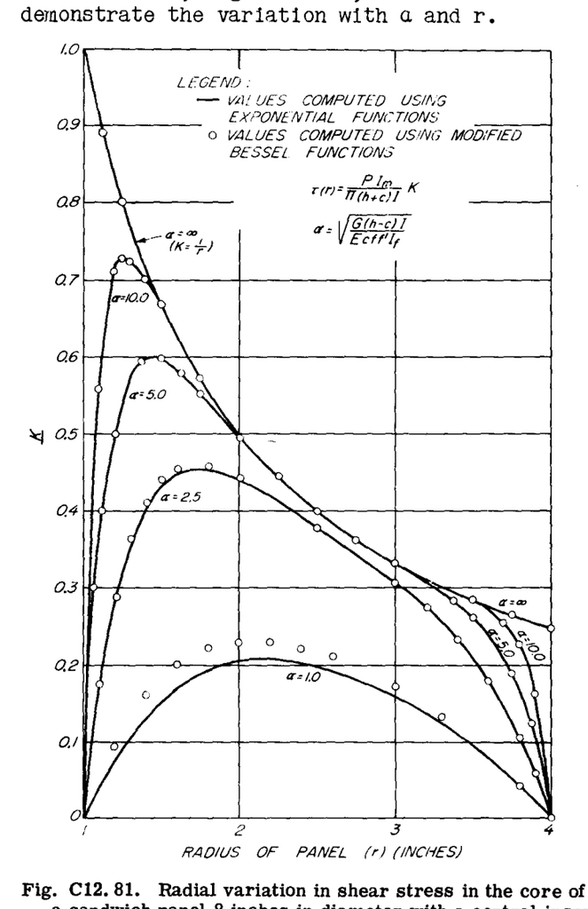

せん断応力分布のグラフ

計算されたせん断応力は、節 C12.4.5 の許容コアせん断応力と比較されなければならない。

## C12.9 波形コアサンドイッチの破壊モード - 文献 10

### C12.9.1 概要

利用可能な多種多様なサンドイッチ構造の中で、重要な2つのタイプは、等方性コアを持つものと波形コアを持つものである。等方性面シートを持つサンドイッチ板の安定性分析の基本理論は、技術文献で発表されている。これらの理論の広範な適用は、複合面内荷重下の等方性またはほぼ等方性のコアサンドイッチに対して与えられてきた。非常に直交異方性の高いコアの中で、波形コアは重要な実用的用途を持ち、文献10の論文で考慮され本節で提示されているタイプである。

等方性パネルの様々な面内荷重下での処理は広範囲に行われてきたが、波形コアサンドイッチに対する同様の処理は幾分制限されていた。本節では、文献11で形式化された理論のバリエーションを使用して、面内、複合縦方向圧縮および曲げ、横方向圧縮および曲げ、およびせん断を受ける波形コアサンドイッチのこれらのケースに対する解決策を提示する。

本論文で考慮されている理想化された波形コアサンドイッチパネル（Fig. C12.9.1 に示す）の基本要素は、比較的薄い等方性面シートで構成されており、それらは独自の重心軸の周りに無視できるほどの曲げ剛性を持ち、非常に直交異方性の高いコアに対しては、せん断変形が波形に垂直な平面内でのみ許容されると仮定されている。さらに、コアの曲げ剛性は横方向には無視できると仮定されている。一般に、波形コアの場合、コアせん断弾性率は、波形に沿った平面内（縦方向）の方が、波形に直交する方向（横方向）よりも何倍も大きい。また、せん断変形に関する上記の仮定は、多くのそのような構成に対して現実的であると思われる。面シートとコアは両方とも弾性であると仮定されている。

本節で波形サンドイッチパネルに対して開発された一般座屈許容値に加えて、局所不安定性も考慮されなければならない。波形サンドイッチパネル要素の局所座屈は、それぞれの要素タイプおよび要素荷重に対して $K$ を使用する標準的な等方性パネル座屈方程式

$$F_{\text{cR}} = K E \left(\frac{t}{b}\right)^2$$

を使用して処理できる。